# Characterizing Automobiles

Author

Charlie Wiebe

Published

March 17, 2025

# Setup

- Setup

```r
sh <- suppressPackageStartupMessages
sh(library(tidyverse))
sh(library(caret))
sh(library(fastDummies))
sh(library(class))
sh(library(ISLR)) # for the "Auto" dataframe
sh(library(pROC))
```

# Dataframe

- We use the `Auto` dataframe.

```r
head(Auto)
```

```
  mpg cylinders displacement horsepower weight acceleration year origin
1  18         8          307        130   3504         12.0   70      1
2  15         8          350        165   3693         11.5   70      1
3  18         8          318        150   3436         11.0   70      1
4  16         8          304        150   3433         12.0   70      1
5  17         8          302        140   3449         10.5   70      1
6  15         8          429        198   4341         10.0   70      1
                       name
1 chevrolet chevelle malibu
2         buick skylark 320
3        plymouth satellite
4             amc rebel sst
5               ford torino
6          ford galaxie 500
```

- It has the following variable names, which describe various attributes of automobiles.

```r
names(Auto)
```

```
[1] "mpg"          "cylinders"    "displacement" "horsepower"   "weight"
[6] "acceleration" "year"         "origin"       "name"
```

# Multiple Regression

- Run a linear regression model with `mpg` as the dependent variable and `horsepower` and `year` as features (variables).
- Compute and comment on the RMSE.

```r
mod <- lm(mpg ~ horsepower + year, Auto)
summary(mod)
```

```
Call:
lm(formula = mpg ~ horsepower + year, data = Auto)

Residuals:
     Min       1Q   Median       3Q      Max
-12.0768  -3.0783  -0.4308   2.5884  15.3153

Coefficients:
              Estimate Std. Error t value Pr(>|t|)
(Intercept) -12.739166   5.349027  -2.382   0.0177 *
horsepower   -0.131654   0.006341 -20.761   <2e-16 ***
year          0.657268   0.066262   9.919   <2e-16 ***
---
Signif. codes:  0 '***' 0.001 '**' 0.01 '*' 0.05 '.' 0.1 ' ' 1

Residual standard error: 4.388 on 389 degrees of freedom
Multiple R-squared:  0.6855,    Adjusted R-squared:  0.6839
F-statistic: 423.9 on 2 and 389 DF,  p-value: < 2.2e-16
```

```r
# RSE is 4.388

predictions <- predict(mod, Auto)
actuals <- Auto$mpg
rmse <- sqrt(mean((actuals - predictions)^2))
cat("RMSE:", rmse)
```

```
RMSE: 4.371506
```

> TODO: *The RMSE here is 4.372. On average, the model’s predictions deviate from the actual MPG values by 4.372. The mpg values in the dataset are typically between 10 and 40, which leads me to believe that the RMSE value in this case isn’t bad, but there’s definitely room for improvement.*

# Feature Engineering

- Create 10 features based on the `name` column.
- Remove all rows with a missing value.
- Ensure only `mpg` and the engineered features remain.
- Compute and comment on the RMSE.

```r
auto_fe <- Auto %>%
  mutate(diesel = ifelse(str_detect(name, "diesel"), 1, 0),
         manufacturer = word(name,1),
         station_wagon = ifelse(str_detect(name, "wagon|sw"), 1, 0),
         truck = ifelse(str_detect(name, "pickup|truck"), 1, 0),
         sedan = ifelse(str_detect(name, "sedan"), 1, 0),
         luxury = ifelse(str_detect(name, "mercedes|cadillac|bmw|audi|volvo"), 1, 0),
         american = ifelse(str_detect(name, "ford|chevrolet|dodge|amc|buick|plymouth"), 1, 0),
         special_edition = ifelse(str_detect(name, "deluxe|custom|limited|brougham|se|gl"), 1, 0),
         sport = ifelse(str_detect(name, "coupe|gt|sport|corvette|camaro|mustang|firebird"), 1, 0),
         japanese = ifelse(str_detect(name, "toyota|datsun|honda|mazda|subaru|nissan"), 1, 0))

auto_clean <- auto_fe %>%
  select(mpg, diesel, station_wagon, truck, sedan, luxury, american, special_edition, sport, japanese) %>%
  na.omit()

set.seed(505)
trainIndex <- createDataPartition(auto_clean$mpg, p = 0.8, list = FALSE)
train_data <- auto_clean[trainIndex, ]
test_data <- auto_clean[-trainIndex, ]

model <- lm(mpg ~ ., data = train_data)
summary(model)
```

```
Call:
lm(formula = mpg ~ ., data = train_data)

Residuals:
     Min       1Q   Median       3Q      Max
-14.1377  -4.6154  -0.5674   3.9846  18.9069

Coefficients:
                Estimate Std. Error t value Pr(>|t|)
(Intercept)      23.1377     0.7967  29.043  < 2e-16 ***
diesel           16.9847     2.8806   5.896 9.85e-09 ***
station_wagon    -0.0637     1.1234  -0.057  0.95482
truck            20.8623     6.4007   3.259  0.00124 **
sedan             3.4517     6.5357   0.528  0.59779
luxury           -0.8082     1.7675  -0.457  0.64780
american         -3.0446     0.9018  -3.376  0.00083 ***
special_edition  -0.5257     1.1312  -0.465  0.64244
sport            -0.2751     1.8033  -0.153  0.87885
japanese          7.9959     1.1145   7.174 5.54e-12 ***
---
Signif. codes:  0 '***' 0.001 '**' 0.01 '*' 0.05 '.' 0.1 ' ' 1

Residual standard error: 6.351 on 305 degrees of freedom
Multiple R-squared:  0.3776,    Adjusted R-squared:  0.3592
F-statistic: 20.56 on 9 and 305 DF,  p-value: < 2.2e-16
```

```r
predictions <- predict(model, newdata = test_data)

rmse <- sqrt(mean((test_data$mpg - predictions)^2))
print(paste("RMSE:", round(rmse, 3)))
```

```
[1] "RMSE: 6.981"
```

> TODO: *The RMSE for this model is 6.981. On average, the predicted mpg values deviate from their actual values by 6.981. This is worse than the RMSE of the model that used only horsepower and year as features. Because the mpg values in the dataset are typically between 10 and 40, there is considerable room for improvement in this model.*

# Classification

- Use either of $K$-NN or Naive Bayes to predict whether an automobile is a `chevrolet` or a `honda`.
- Explain your choice of technique.
- Report on your Kappa value.

```r
set.seed(505)

auto_class <- Auto %>%
  mutate(manufacturer = word(name, 1)) %>%
  filter(manufacturer %in% c("chevrolet", "honda")) %>%
  select(mpg, horsepower, weight, acceleration, year, manufacturer)

auto_class$manufacturer <- as.factor(auto_class$manufacturer)

split <- createDataPartition(auto_class$manufacturer, p = 0.8, list = FALSE)
train <- auto_class[split, ]
test <- auto_class[-split, ]

fit <- train(manufacturer ~ .,
             data = train,
             method = "knn",
             tuneLength = 15,
             metric = "Kappa",
             trControl = trainControl(method = "cv", number = 5))
confusionMatrix(predict(fit, test),factor(test$manufacturer))$overall['Kappa']
```

```
    Kappa
0.6153846
```

```r
confusionMatrix(predict(fit, test),factor(test$manufacturer))
```

```
Confusion Matrix and Statistics

           Reference
Prediction  chevrolet honda
  chevrolet         8     1
  honda             0     1

               Accuracy : 0.9
                 95% CI : (0.555, 0.9975)
    No Information Rate : 0.8
    P-Value [Acc > NIR] : 0.3758

                  Kappa : 0.6154

 Mcnemar's Test P-Value : 1.0000

            Sensitivity : 1.0000
            Specificity : 0.5000
         Pos Pred Value : 0.8889
         Neg Pred Value : 1.0000
             Prevalence : 0.8000
         Detection Rate : 0.8000
   Detection Prevalence : 0.9000
      Balanced Accuracy : 0.7500

       'Positive' Class : chevrolet
```

> TODO: *I chose to use K-NN instead of Naive Bayes because I didn’t want to make the assumptions of Naive Bayes (that the data follows a specific distribution). Naive Bayes also assumes that the features are independent of each other, but this is simply not true with this dataset- many of the features are intertwined with each other. The kappa of this model is 0.615, which indicates that it is doing a decent job of predicting whether a car is a Chevrolet or a Honda, but can be improved. I’m also slightly wary about this value just because the testing set is so small, and thus is more vulnerable to random chance messing with the results.*

# Binary Classification

- Predict whether a car is a `honda`.
- Use model weights.
- Display and comment on an ROC curve.

```r
auto_class <- Auto %>%
  mutate(manufacturer = word(name, 1)) %>%
  mutate(honda = ifelse(manufacturer == "honda", "Honda", "Nonda")) %>%
  select(mpg, horsepower, weight, acceleration, year, honda)

auto_class$honda <- as.factor(auto_class$honda)

print(levels(auto_class$honda))
```

```
[1] "Honda" "Nonda"
```

```r
set.seed(505)
trainIndex <- createDataPartition(auto_class$honda, p = 0.7, list = FALSE)
train_data <- auto_class[trainIndex, ]
test_data <- auto_class[-trainIndex, ]

table(auto_class$honda)
```

```
Honda Nonda
   13   379
```

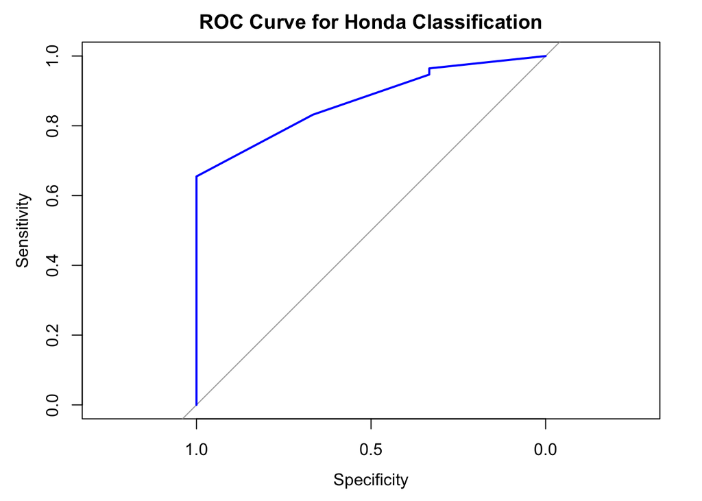

```r
# 13 Hondas, 379 Non-Hondas (Nondas)
# 379 / 13 ~= 29
weights <- ifelse(train_data$honda == "Honda", 29, 1)

fit <- train(honda ~ .,
             data = train_data,
             method = "knn",
             tuneLength = 15,
             weights = weights,
             trControl = trainControl(method = "cv", number = 5, classProbs = TRUE))

probabilities <- predict(fit, test_data, type = "prob")[, "Honda"]

roc_curve <- roc(test_data$honda, probabilities)
plot(roc_curve, main = "ROC Curve for Honda Classification", col = "blue", lwd = 2)
```

```r
auc_value <- auc(roc_curve)
cat("AUC: ", auc_value, "\n")
```

```
AUC:  0.8716814
```

> TODO: *I’m quite happy with the area under the curve for this model, which is 0.872. This suggests that the model can effectively distinguish between Hondas and other vehicles. This conclusion is supported by the ROC curve itself. The blue line hugs the top left corner, which indicates a strong model, whereas a model with an ROC curve that is close to the diagonal line would suggest random guessing and a weak model.*

# Ethics

- Based on your analysis, comment on the [Clean Air Act of 1970 and Ammendments of 1977](https://www.epa.gov/clean-air-act-overview/evolution-clean-air-act)
- Discuss the civic reposibilities of data scientists for:
  - Big Data and Human-Centered Computing
  - Democratic Institutions
  - Climate Change
- Provide at least one statistical measure for each, such as a RMSE, Kappa value, or ROC curve.

> TODO: Big Data and Human-Centered Computing

```r
# The Clean Air Act of 1970 and its 1977 Amendments established a framework between federal and state governments that ensures air quality standards are met through shared responsibility. Similarly, data scientists must work collaboratively to ensure integrity, transparency, and accountability in their analyses, as well as lack of bias and discrimination in their data. To give an example that is specific to the Auto dataset we've been looking at, Kappa can be used to measure agreement between human inspectors and automated systems when classifying vehicles based on emissions compliance or fuel efficiency standards. Moreover, a Kappa value of 0.8 or higher would indicate strong reliability, ensuring that regulatory actions, such as identifying high-emission vehicles or enforcing fuel efficiency standards, are based on accurate and consistent data.
```

> TODO: Democratic Institutions

```r
# Data scientists play a critical role in supporting democratic institutions by ensuring the integrity and transparency of data used in policymaking and regulation. Additionally, as we move forward toward a more AI-dependent future, we must work hard to ensure that the people controlling language-learning models and their algorithms do not have political interests or personal biases in mind. This must be done with a robust and transparent system of checks and balances. For instance, when evaluating the fairness and accuracy of AI models used in public decision-making, data scientists can employ the ROC curve to assess how well the model distinguishes between different outcomes. A high AUC would indicate strong discriminatory power, ensuring that the model is both accurate and fair. This statistical measure helps ensure that AI systems are not only effective but also unbiased, fostering trust in democratic processes and aligning with the principles of transparency and accountability championed by the Clean Air Act of 1970 and its 1977 Amendments.
```

> TODO: Climate Change

```r
# The Clean Air Act of 1970 and its 1977 Amendments were instrumental in reducing air pollution and addressing environmental challenges. Today, data scientists have a critical role in combating climate change by developing models to predict emissions, monitor environmental impacts, and inform mitigation strategies. For an example that is specific to the Auto dataset, RMSE can be used to evaluate the accuracy of a model predicting vehicle fuel efficiency (mpg). A lower RMSE would indicate better predictive performance, helping policymakers design effective regulations to reduce greenhouse gas emissions.
```